# EEG RTool – Herramienta web para el análisis, procesamiento y visualización de las señales del EEG

Manual de usuario

Alumno. José María Sánchez Salas

Tutor. José Tomás Palma Méndez

Universidad de Murcia. Curso 2016/2017

# 1 Introducción

En este documento se expone un breve manual de uso de la herramienta web EEG RTool diseñada como Trabajo Fin de Grado por José María Sánchez Salas y tutorizada por Dr. D. José Tomás Palma Méndez, como finalización del Grado en Ingeniería en Informática, realizado en la Facultad de Informática de la Universidad de Murcia, en el curso académico 2016/2017.

La finalidad de esta herramienta es la de proporcionar un mecanismo automático (o manual, si se quiere) para el cálculo de cuatro índices que se obtienen a partir del análisis del electroenfecalograma (EEG). Estos cuatro índices son los siguientes: *Índice de Atención (AI), Índice de Aproximación-Rechazo (AW), Índice de Compromiso (EI) e Índice de Memorización (MI)*.

Esta herramienta proporciona mecanismos para poder visualizar las señales que se han obtenido tras la realización de distintas pruebas a un sujeto, como puede ser señales del electroencefalograma (EEG), del electrooculograma (EOG), ritmo cardíaco, etc. Permite la adecuación tanto de las señales del EEG como del EOG para poder aplicar una posterior corrección ocular del EEG haciendo uso del EOG.

Con las señales del EEG corregidas, ya se puede empezar a realizar ciertos pasos para el cálculo de los índices. El primero de ellos es segmentar la señal en las bandas $\alpha$, $\beta$ y $\theta$ para cada una de las tareas realizadas al sujeto. El segundo es calcular los valores de referencia para el cálculo de los índices. Estos valores de referencia se obtienen a partir de la **fase basal** (o fases basales en el caso de que hayan varias). Por último, con estos valores de referencia se obtienen los valores de los índices para cada una de las tareas.

Esta herramienta permite que tanto las señales filtradas, como las señales corregidas, así como la segmentación de la señal en bandas, los valores de referencia para el cálculo de los índices y los propios valores de los índices para cada tarea, sean visualizados.

De igual manera que proporciona los mecanismos paso por paso para el cálculo de los índices, también proporciona la ejecución de todo el proceso de manera automática. Además, permite exportar los datos obtenidos: tanto los valores de los índices para cada una de las tareas, como las señales empleadas en su cálculo.

La estructura de este manual sigue toda la funcionalidad de la herramienta, desde la carga de los datos, hasta la exportación de los datos. Por lo tanto, en las siguientes secciones se detallará más concretamente cómo se ha de realizar cada uno de los pasos.

# 2 Carga de los datos

Para que el usuario pueda cargar los datos, la herramienta proporciona la pestaña *Load Data*, cuya interfaz es la que se muestra en la imagen:

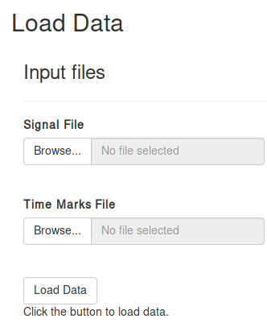

Como se puede observar, presenta dos buscadores, en los que se tienen que introducir las rutas a los ficheros de señales y de marcas de tiempo, correspondientemente. Es importante destacar que el usuario debe introducir ambos ficheros de manera que sean correspondientes. Es decir, si el fichero de señales se llama *Datos1.txt* el fichero de marcas de tiempo debe tener el nombre *Test-Datos1.txt*. Si no es así, la herramienta mostrará un mensaje de error.

Una vez que se hayan seleccionado los dos ficheros, entonces se pueden cargar pulsando el botón *Load Data*. Mientras se cargan, la herramienta mostrará un mensaje indicando que se están cargando los datos. Tras finalizar, mostrará un mensaje diciendo que la carga ha sido correcta.

La herramienta permite que el usuario pueda cargar tantos datos como desee. Esto es, la herramienta no se limita a poder procesar los datos de un único sujeto, sino que permite la carga de varios sujetos y posteriormente, seleccionar aquel con el que se quiera trabajar.

# 3 Selección de datos

Como se ha comentado en la sección anterior, la herramienta permite que el usuario pueda subir tantos datos de sujetos como desee. Pero el procesamiento de los sujetos debe ser individual, por lo que es necesario, previo al procesamiento, que se seleccione aquel sujeto con el que se quiera trabajar. Esta funcionalidad la proporciona la pestaña *Select Data* cuya interfaz se muestra en la siguiente imagen:

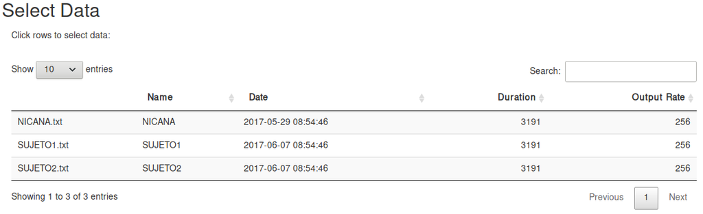

Se trata de una tabla en la que se muestran todos los sujetos cargados: el nombre del fichero de señales (parte izquierda), el nombre de la sesión, la fecha y duración de la prueba, así como la frecuencia de muestreo. Esta interfaz permite modificar el número de sujetos que se muestran en la tabla, así como buscar en la tabla por el valor de algún campo.

Para seleccionar el sujeto con el que se quiere trabajar, solamente hace falta seleccionar la fila de la tabla correspondiente. Tras esto, la herramienta mostrará un mensaje indicando qué datos han sido seleccionados.

# 4 Visualización de señales

La visualización de las señales se encuentra en la pestaña *Display Signals*, cuya interfaz es la que se muestra en la siguiente imagen:

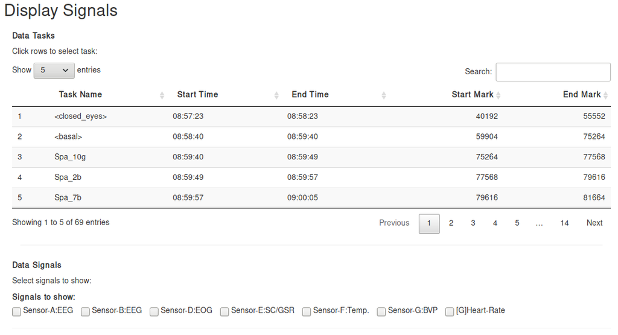

Esta interfaz se divide en dos partes:

- Una tabla con todas las tareas realizadas al sujeto, que contiene:
  - El nombre de la tarea.
  - La hora de inicio.
  - La hora de finalización.
  - La marca de tiempo de inicio.
  - La marca de tiempo de finalización.
- Un *checkbox* donde se pueden seleccionar aquellas señales que se quieran visualizar.

Puede haber cierta confusión en cuanto a la hora y marca de inicio y finalización. La hora indica la hora real y exacta en la que se realizó y finalizó la tarea, mientras que la marca de tiempo indica, de toda la señal capturada, dónde comienza y termina dicha tarea.

Por defecto, si se selecciona cualquiera de las señales en el *checkbox*, la aplicación mostrará una gráfica con toda la señal. Sin embargo, se pueden visualizar las señales para una tarea en concreto. Para ello, es necesario que se seleccione la tarea concreta en la tabla de tareas. Una vez que la tarea ha sido seleccionada, todas las señales serán visualizadas para esa tarea.

La siguiente imagen muestra un ejemplo de visualización de la señal *Sensor-A:EEG* para la tarea *Spa_10g*:

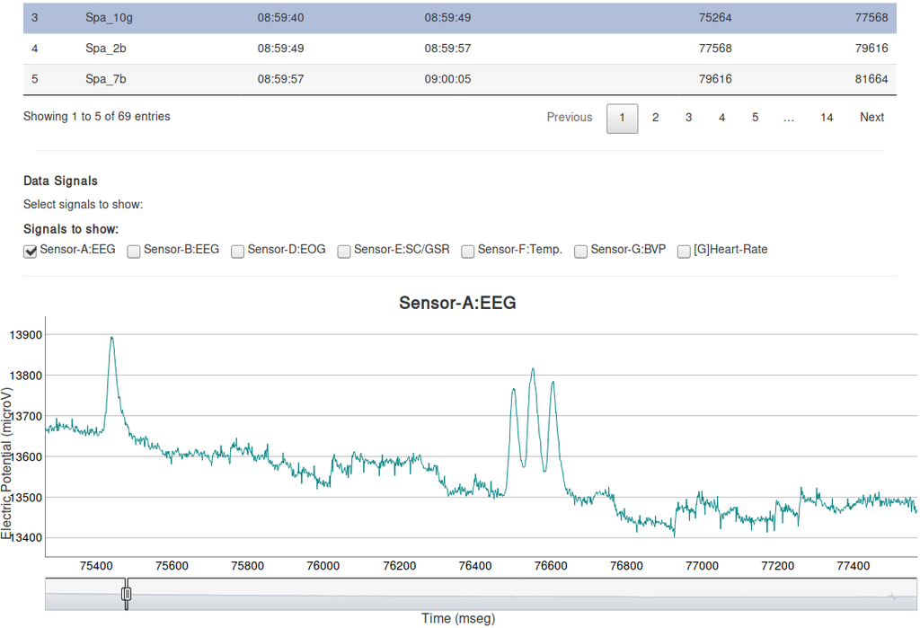

Todas las gráficas que se muestran en la herramienta son interactivas. La interactividad con la que cuentan estas gráficas son:

- Ampliación/Reducción de la visualización de los datos. La gráfica permite que se pueda ampliar una zona de la gráfica para que se pueda ver con mayor detenimiento. Esto se consigue seleccionando con el ratón la región de la gráfica que se quiera ampliar, clickando en un punto inicial de la gráfica y arrastrando hasta el punto final donde se quiere hacer zoom. Para restablecer este zoom, hay dos mecanismos: haciendo doble click en la gráfica o pulsando el botón *Reset Zoom* que aparecerá en la parte superior izquierda de la gráfica. Las siguientes imágenes reflejan cómo se realiza la ampliación en la gráfica y el resultado obtenido (para la misma señal que en la imagen anterior), (nótese que la región que se va a ampliar es la marcada de color más oscuro en la gráfica):

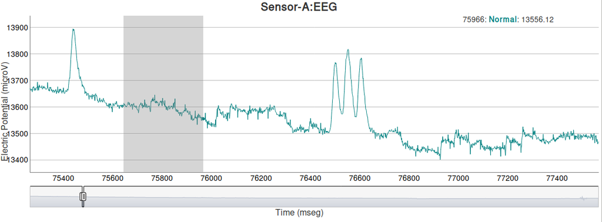

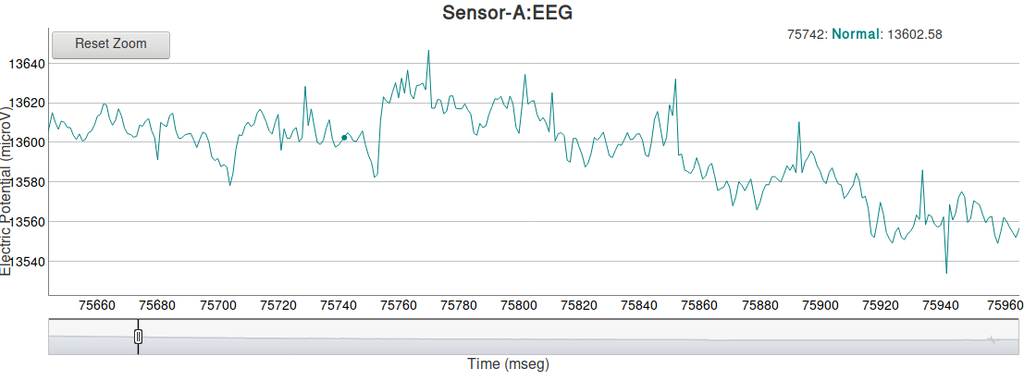

- Visualización del valor de la gráfica en un determinado punto. Como se ha podido ver en la imagen anterior, en la gráfica aparece un punto sobre la señal. Para ese punto, la gráfica muestra su valor en el eje de abscisas (en mseg) seguido de su valor en el eje de ordenadas (en microV), en la parte superior derecha. La obtención de cualquiera de los puntos de la gráfica se consigue pasando el ratón por la gráfica: esta lo detectará e irá mostrando los valores de los puntos por lo que se va pasando.
- Como se puede observar, en todas las gráficas, en la parte inferior, aparece una barra deslizadora con un selector de rango. Esta barra deslizadora refleja toda la señal completa, mientras que el selector de rango permite al usuario visualizar el rango de la señal que él quiera, de manera independiente a si se ha seleccionado una tarea o se ha visualizado la señal completa. De esta manera, moviendo el selector de rango, se modifica el rango de visualización de la señal (incluso se puede seleccionar toda la señal).

# 5 Filtrado de señales

La pestaña que proporciona la funcionalidad de realizar el filtrado de las señales es la pestaña *Signal Filtering*, que tiene la interfaz que se muestra en la siguiente imagen:

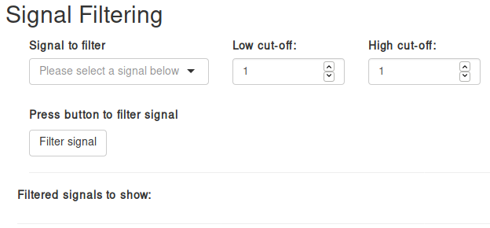

Esta interfaz presenta un selector donde se muestran las señales que pueden ser filtradas y al lado dos componentes numéricos que establecen la banda inferior y la banda superior que se quiere aplicar para el filtrado de la señal. Por defecto, la herramienta, cuando se selecciona una de las señales, establece en estos componentes, los valores de las bandas que se suelen aplicar: 2-30Hz para las señales del EEG y 0.1-5Hz para las señales del EOG. Aunque estos valores pueden ser cambiados por el usuario si quiere realizar un filtrado para otras bandas.

Una vez que se haya seleccionado la señal y establecido las bandas, para realizar el filtrado de la señal hay que pulsar el botón *Filter signal*. Mientras se está filtrando la señal, la herramienta mostrará un mensaje indicándolo y cuando termine, mostrará otro mensaje indicando que el filtrado se ha realizado correctamente o un mensaje de error si ha habido algún problema en el filtrado.

En la parte inferior, donde pone **Filtered signals to show** irán apareciendo aquellas señales que ya hayan sido filtradas, en un *checkbox*, de manera que se pueda seleccionar y visualizar la respuesta en frecuencia de la señal filtrada, para comprobar que el filtrado ha sido correcto. En la imagen siguiente, aparece un ejemplo de visualización de la respuesta en frecuencia de las señales *Sensor-A:EEG* y *Sensor-B:EEG*, filtradas en el rango 2-30Hz:

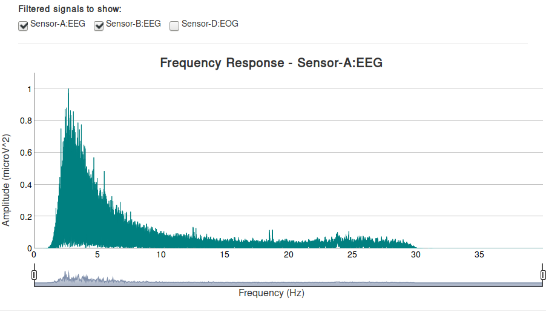

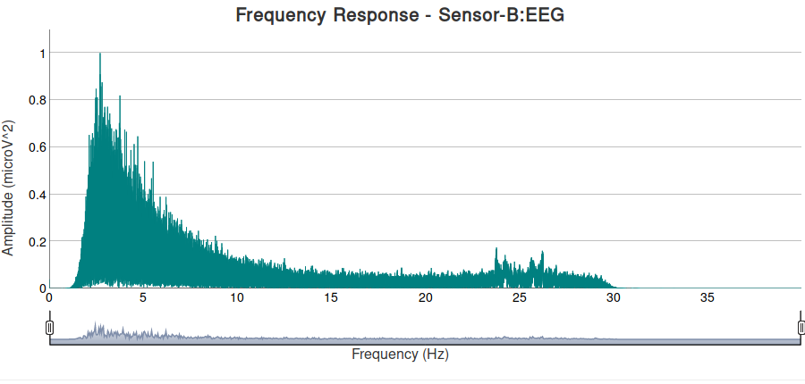

# 6 Corrección ocular

Para la aplicación de la correción ocular, la pestaña *Ocular Correction* desempeña esta función proporcionando la siguiente interfaz:

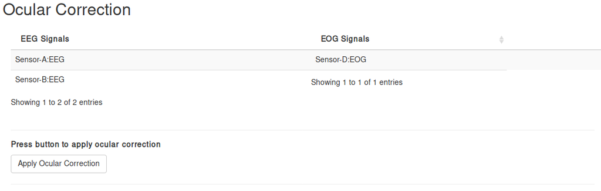

En esta interfaz se muestran dos tablas: una con todas las señales correspondientes al EEG y otra con todas las señales correspondientes al EOG. Estas tablas están para visualizar aquellas señales que se van a tener en cuenta para la aplicación de la corrección ocular. Es importante destacar que para poder realizar la corrección ocular, por el algoritmo que se utiliza (algoritmo de Gratton), solamente debe haber una única señal del EOG, mientras que pueden haber diversas señales del EEG. En el caso de que haya más de una señal del EOG, la herramienta mostrará un mensaje de error indicando esta situación.

Para la aplicación de la corrección ocular, hay que pulsar el botón *Apply Ocular Correction*, tras lo cual el sistema mostrará un mensaje indicando que está realizando la corrección ocular y cuando termine, si todo ha ido correctamente, mostrará un mensaje diciendo que se ha aplicado correctamente, y si no, mostrará un mensaje de error.

Tras la aplicación de la corrección ocular, la herramienta proporcionará, debajo del botón *Apply Ocular Correction*, un *checkbox* similar al visto en el filtrado de las señales, con el que se puede visualizar las señales corregidas. La imagen siguiente muestra un fragmento de la señal *Sensor-A:EEG* corregida:

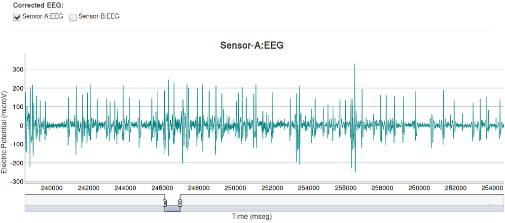

# 7 Segmentación por bandas

La segmentación por bandas se encuentra dividida en tres subpestañas: *Calculate Bands Segmentation*, *Display GPS Signal* y *Display Bands Filtering*, dentro de la pestaña-menú *Bands Segmentation*. Las siguientes subsecciones corresponden a cada una de las subpestañas mencionadas.

## 7.1 Cálculo de la segmentación por bandas

La subpestaña *Calculate Bands Segmentation* es la que se encarga de realizar todas las operaciones para la segmentación por bandas de la señal: segmenta por tareas la señal completa, calcula la señal GPS para obtener el valor de la IAF y con este valor aplica el filtrado de las bandas $\alpha$, $\beta$ y $\theta$ para cada tarea. La interfaz que tiene se muestra en la siguiente imagen:

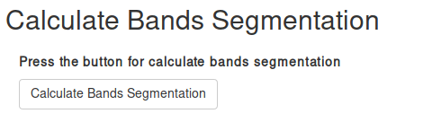

Como se puede observar, solamente hay que pulsar el botón *Calculate Bands Segmentation* para realizar la segmentación de las bandas. Una vez pulsado, la herramienta mostrará mensajes sobre la realización de pasos que va haciendo, por último, mostrará un mensaje indicando que ha terminado de realizar la segmentación.

## 7.2 Visualización de la señal GPS

La subpestaña *Display GPS Signal* se encarga de visualizar la señal GPS junto con el valor de la IAF. La interfaz que presenta es la siguiente:

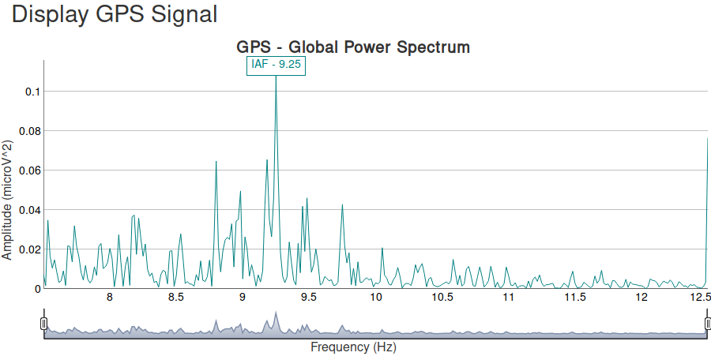

## 7.3 Visualización de la segmentación por bandas para cada tarea

La subpestaña *Display Bands Filtering* se encarga de visualizar, para cada tarea, el filtrado de las bandas $\alpha$, $\beta$ y $\theta$, así como de la señal corregida. La interfaz es la que se muestra en la siguiente imagen:

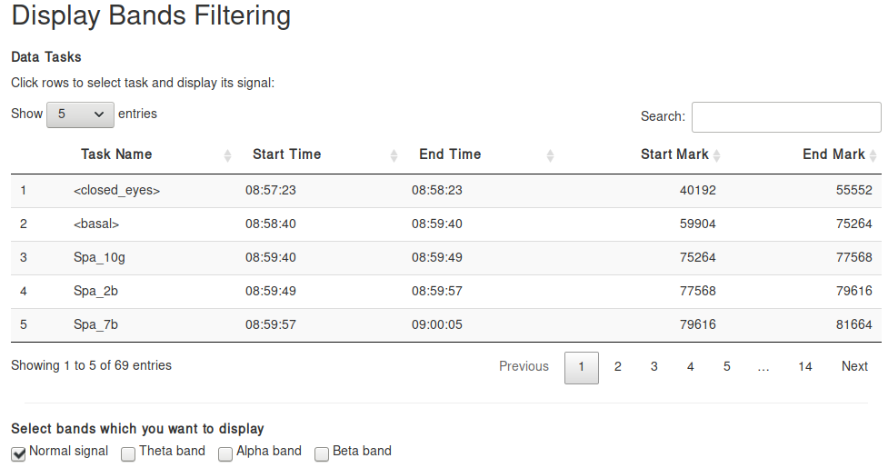

Como se puede observar, también dispone de un *checkbox* en la parte inferior en la que se puede elegir las bandas que se quieren visualizar. Para que se puedan visualizar, hay que seleccionar cualquiera de las tareas mostradas en la tabla. La imagen siguiente muestra cómo se visualizaría la señal normal y su banda $\alpha$, para las señales *Sensor-A:EEG* y *Sensor-B:EEG*, de manera conjunta para la tarea *Spa_10g*:

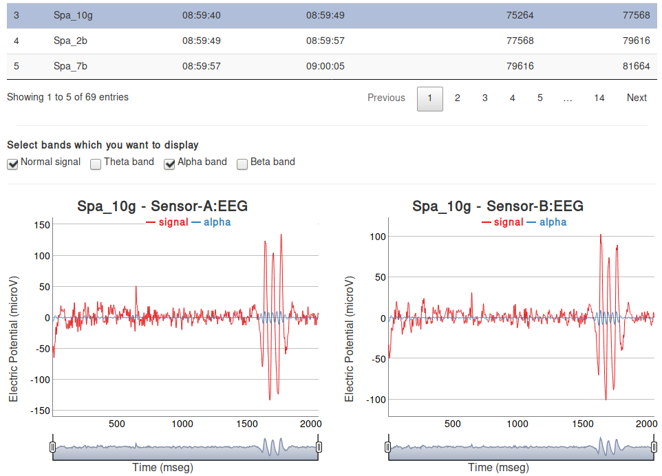

Como podemos observar, las gráfica permite visualizar distintas señales de manera conjunta y las diferencia por colores, cuya leyenda se encuentra en la parte superior de la gráfica. Cabe destacar que se pueden visualizar todas las bandas, así como la señal corregida, de manera simultánea. En la imagen anterior solamente se ha visualizado la señal corregida y la banda $\alpha$ para no mostrar gráficas con mucha información.

# 8 Cálculo de los índices

Al igual que pasa con la segmentación por bandas, el cálculo de los índices se encuentra dividido en tres subpestañas: *Calculate Indices*, *Display Values of Reference* y *Display Indices*, dentro de la pestaña-menú *Indices Calculation*. Las siguientes subsecciones corresponden a cada una de las subpestañas mencionadas.

## 8.1 Cálculo de los índices

La subpestaña *Calculate Indices* es la que se encarga de realizar los cálculos necesarios para la obtención de los índices: obtiene los valores de referencia de la fase basal y con ellos obtiene el cálculo de los índices para cada tarea. La interfaz que presenta es similar a la del cálculo de la segmentación por bandas, y es la que se muestra en la siguiente imagen:

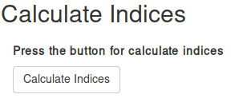

De igual manera que en el cálculo de la segmentación por bandas, solamente hay que pulsar el botón *Calculate Indices* para que la herramienta realize el cálculo de los índices. La herramienta mostrará un mensaje indicando que está realizando el cálculo y cuando termine mostrará otro mensaje indicando que ha terminado.

## 8.2 Visualización de los valores de referencia

La subpestaña *Display Values of Reference* se encarga de visualizar los valores de referencia que se han calculado para la obtención de los índices. Su interfaz es la que se muestra en la siguiente imagen:

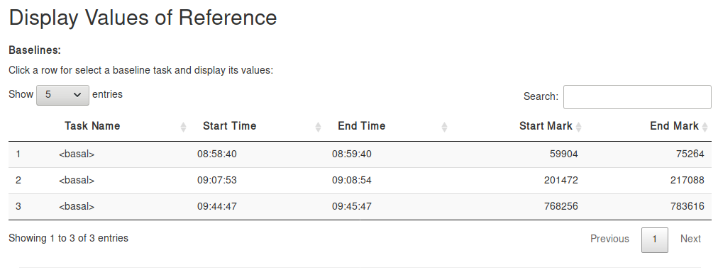

La tabla que aparece muestra la información de las **fases basales** que se han realizado al sujeto. Pues en el caso de que se hayan realizado varias fases basales al sujeto, hay que calcular tantos valores de referencia como fases basales. De esta manera, para el cálculo posterior de los índices, para una determinada tarea, se usarán los valores de referencia de la **última fase basal realizada**.

Para obtener los valores de referencia de una fase basal, simplemente se ha de seleccionar la fase basal que se quiera de la tabla y aparecerá su información en la parte inferior, tal y como muestra la siguiente imagen:

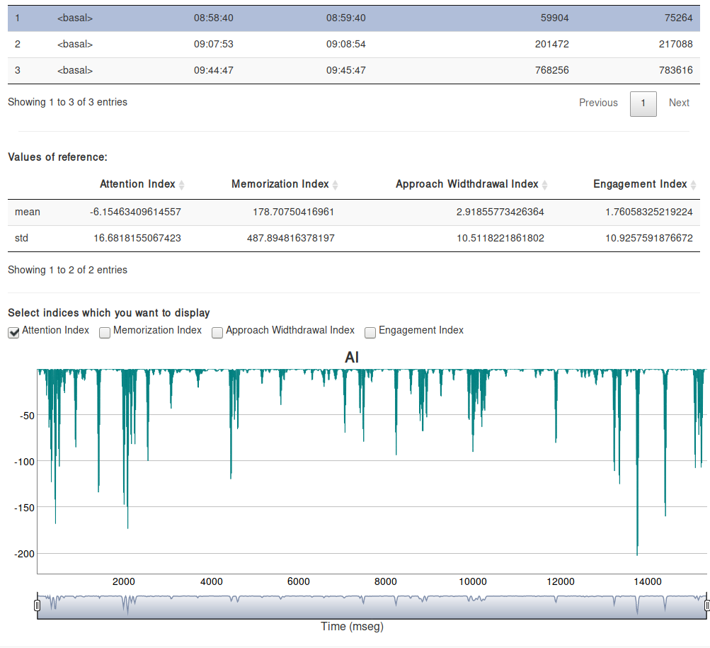

Como se puede observar, cuenta con una tabla en la que aparece la media y la desviación típica calculados para cada índice. También se puede visualizar los índices punto-a-punto, seleccionándolos en el *checkbox* justo debajo de la tabla.

## 8.3 Visualización de los índices para cada tarea

La subpestaña *Display Indices* se encarga de visualizar el valor de los índices para cada tarea, así de visualizar dicho índice punto-a-punto. Cuenta con la interfaz expuesta en la siguiente imagen:

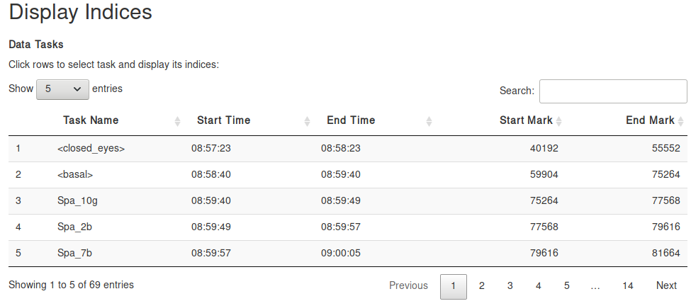

Solamente se muestra una tabla con todas las tareas. Para que se pueda obtener información sobre los índices, hay que seleccionar cualquiera de las tareas, y se visualizará una tabla con los valores de todos los índices, además de un *checkbox* similar al de la visualización de los valores de referencia. La imagen siguiente muestra los valores de los índices para la tarea *Spa_10g* y la visualización del índice AI punto-a-punto:

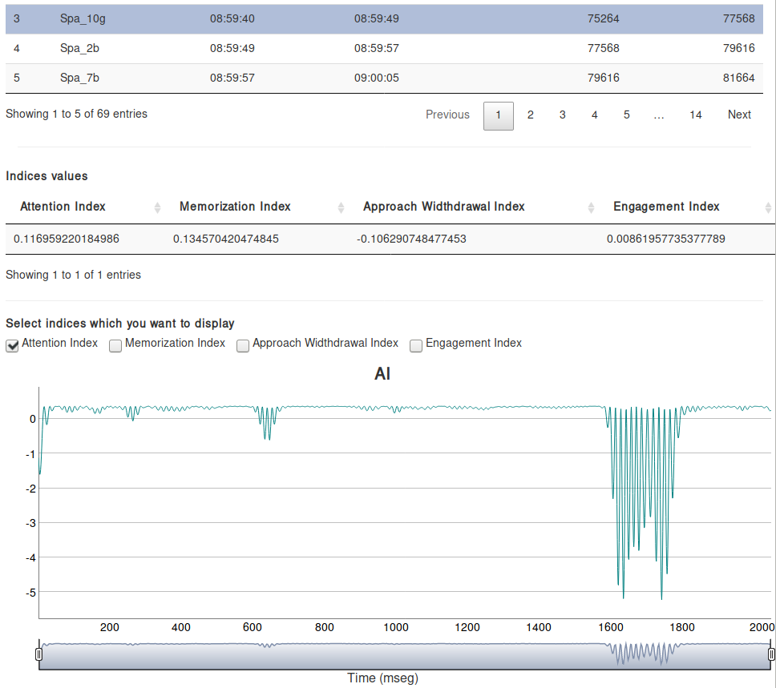

# 9 Ejecución automática de todo el proceso

Para que el usuario pueda lanzar la ejecución automática de todo el proceso, la pestaña *Execute All Process* proporciona la siguiente interfaz:

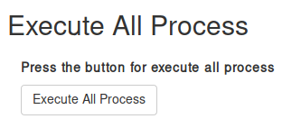

Solamente pulsando el botón *Execute All Process*, la herramienta empezará a realizar, de manera automática, todos los pasos necesarios para el cálculo de los índices: filtrado de las señales, corrección ocular, segmentación por bandas y cálculo de los índices. Durante la ejecución, muestra mensajes indicando cuál de los pasos está realizando en ese momento. El último mensaje en mostrar es el que indica que todo ha terminado correctamente.

# 10 Exportación de datos

La exportación de los datos obtenidos se divide en dos subpestañas: *Export Indices* y *Export Signals*, dentro de la pestaña-menú *Export Data*. Las siguientes subsecciones corresponden a cada una de las subpestañas mencionadas

## 10.1 Exportación de los índices

La subpestaña *Export Indices* es la que se encarga de exportar los valores de los índices calculados para cada una de las tareas realizadas al sujeto. La interfaz que presenta es la que se muestra en la siguiente imagen:

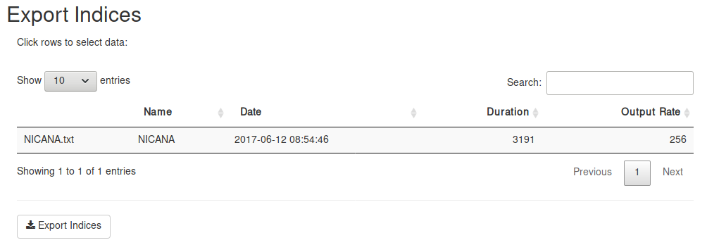

Como se puede observar, muestra una tabla similar a la que se muestra en la pestaña *Select Data* y que muestra todos los datos de los sujetos para los que se han calculado los índices. Esta tabla está para que se pueda seleccionar los datos para los que se quiere exportar el valor de los índices calculados. Por ello es necesario que primero se seleccione cualquiera de los datos y se pulse al botón *Export Indices*. Una vez que se haya seleccionado los datos y se haya pulsado al botón, la herramienta generará un fichero en formato *CSV* para que el usuario pueda descargarlo. La siguiente imagen muestra qué es lo que sucede tras pulsar el botón *Export Indices*:

[figure not shown]

El fichero que se genera tiene como nombre *indices-[Nombre_Fichero_Señales]-[Fecha].csv*, indicando que son los valores de los índices calculados (*indices*) para el fichero de señales cargado (*[Nombre_Fichero_Señales]*) y en la fecha (*[Fecha]*) en la que se calcularon. Este fichero contendrá tantas columnas como índices calculados y tantas filas como tareas se hayan realizado al sujeto.

## 10.2 Exportación de las señales

La subpestaña *Export Signals* es la que se encarga de exportar las señales de las que se han hecho uso para el cálculo de los índices. La interfaz que presenta es la que se muestra en la siguiente imagen:

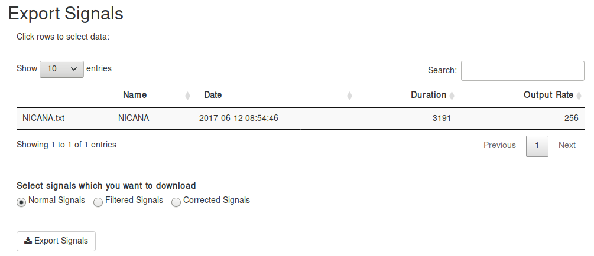

La tabla que aparece es la misma que la que se muestra en la subpestaña *Export Indices* y su finalidad es la misma. Además de la tabla, justo debajo aparece un selector con las señales que se pueden exportar:

- *Normal Signals*, para la exportación de las señales normales.
- *Filtered Signals*, para la exportación de las señales filtradas.
- *Corrected Signals*, para la exportación de las señales corregidas.

Tras haber seleccionado los datos y las señales que se quieren exportar, pulsando el botón *Export Signals*, la herramienta generará un fichero en formato *CSV* para que el usuario pueda descargarlo, de la misma manera que en la pestaña *Export Indices*.

Sin embargo, en este caso, el nombre del fichero cambia según las señales que se quieran exportar: en vez de poner *indices* al inicio del nombre, pondrá *Normal Signals*, *Filtered Signals* o *Corrected Signals*. El resto del nombre sigue la misma estructura que en *Export Indices*.